# Exercise_06_BC

Betsy Cowdery

October 14, 2014

## Bayesian Regression using Gibbs Sampling

The standard Bayesian regression model assumes a Normal likelihood, a Normal prior on the regression parameters, and an Inverse Gamma prior on the variance.

$P(b,\sigma^2 \vert X, y) \propto N_n(y \vert Xb,\sigma^2 I) N_p(b \vert b_0, V_b) IG(\sigma^2 \vert s_1,s_2)$

Within the Gibbs sampler we will be iteratively sampling from each of the conditional posterior distributions:

The regression parameters given the variance

$P(b \vert \sigma^2, X, y) \propto N_n(y \vert Xb,\sigma^2 I) N_p(b \vert b_0, V_b)$

The variance given the regression parameters

$P(\sigma^2 \vert b, X, y) \propto N_n(y \vert Xb,\sigma^2 I) IG(\sigma^2 \vert s_1,s_2)$

### Setup & Evaluation

```r
n <- 500  ## sample size
b0 <- 10  ## intercept
b1 <- 2   ## slope
sigma2 <- 4^2  ## variance (s.d. = 4)
ngibbs <- 10  ## number of updates
par(mfrow = c(1,1))
out <- gibbs_loop(n,ngibbs,b0,b1,sigma2)
```

#### diagnostics of the MCMC

```r
beg = 1; thin = 1;
mcmc_diag(out,beg,thin)
```

```
##
## Iterations = 1:10
## Thinning interval = 1
## Number of chains = 1
## Sample size per chain = 10
##
## 1. Empirical mean and standard deviation for each variable,
##    plus standard error of the mean:
##
##       Mean     SD Naive SE Time-series SE
## [1,] 10.11 0.3187   0.1008         0.1008
## [2,]  1.98 0.0307   0.0097         0.0097
## [3,] 17.22 0.9207   0.2911         0.2911
##
## 2. Quantiles for each variable:
##
##       2.5%   25%  50%  75% 97.5%
## var1  9.86  9.93 10.1 10.1 10.78
## var2  1.92  1.97  2.0  2.0  2.01
## var3 15.94 16.64 17.2 17.5 18.72
```

# Task 1

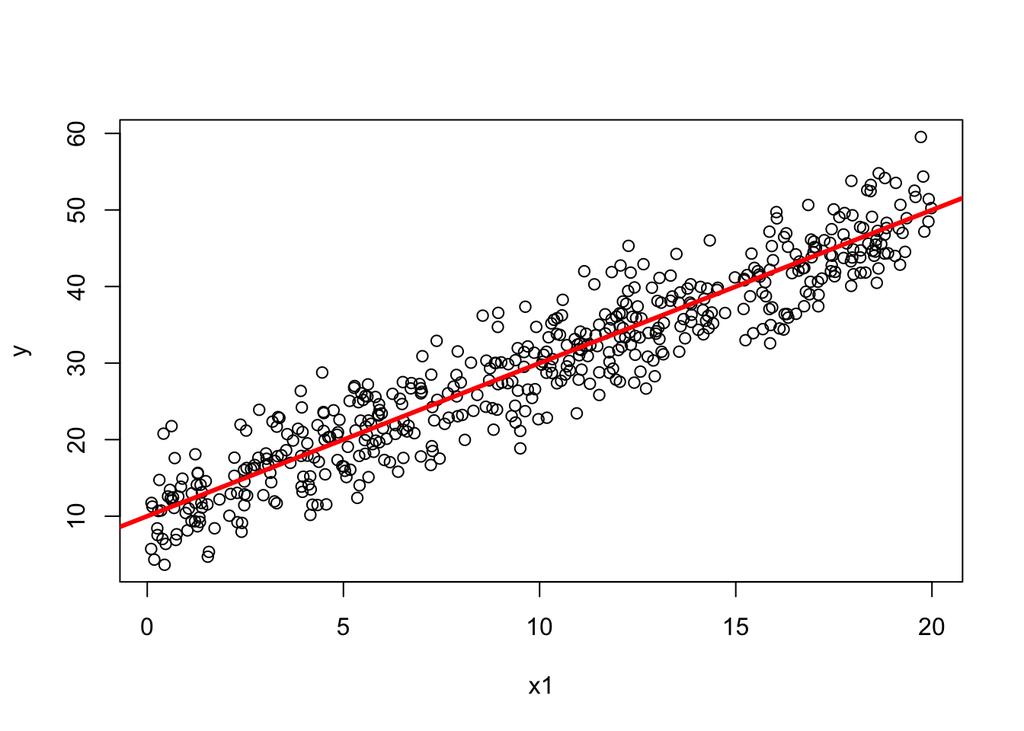

```r
n <- 500
ngibbs <- 5000
out <- gibbs_loop(n,ngibbs,b0,b1,sigma2,plot=T)
```